# Cross-tissue integration task

António Sousa (e-mail: aggode@utu.fi) - Elo lab (https://elolab.utu.fi)

01/07/2024

# Integration task

This single-cell RNA-seq integration task describes an example of cross-tissue integration: human peripheral blood mononuclear cells (PBMCs) with human pancreatic islets. Both data sets were retrieved from the `SeuratData` (v.0.2.2.9001):

- **PBMCs**:
  - `pbmc3k` `SeuratData` data set (v.3.1.4): 3k human PBMCs from 10X Genomics
  - no. of cells: 2,700
- **Pancreas**:
  - `panc8` `SeuratData` data set (v.3.0.2): 8 human pancreas data sets across five technologies (only included the data set `indrop1`)
  - no. of cells (for `indrop1`): 1,937

The identity of the data set - `pbmc` or `pancreas` - for every cell was saved in the `Seurat` `meta.data` column variable `batch`. The ground-truth cell identities were also provided in the column variable `cell_type` but avoid checking them until the end of this notebook to make these analyses more interesting.

The analyses performed in this notebook rely in the `Seurat` R package (v.5.1.0).

Import the main packages used in this notebook: `Seurat` (v.5.1.0), `SeuratWrappers` (v.0.3.2 - integration wrappers for Seurat), `dplyr` (v.1.1.4 - wrangling data), `patchwork` (v.1.2.0 - visualization), `scIntegrationMetrics` (v 1.1 - compute LISI integration metrics).

```r
## Import packages
library("dplyr") # data wrangling
library("Seurat") # scRNA-seq analysis
library("patchwork") # viz
library("SeuratWrappers") # integration wrappers
library("scIntegrationMetrics") # compute LISI integration metrics
```

Create output directories to save intermediate results, figures, tables and R objects.

```r
## Output directories
res.dir <- file.path("../results", "cross_tissue_task", c("plots", "tables", "objects"))
for (folder in res.dir) if (!dir.exists(folder)) dir.create(path = folder, recursive = TRUE)
```

## (1) Import datasets

*(3 min)*

> AIM: Import and explore the Seurat object data.

Import the cross-tissue `Seurat` R object `pbmc3k_panc8.rds` located in the folder `data`.

```r
# Import data
data.dir <- "../data"
seu <- readRDS(file = file.path(data.dir, "pbmc3k_panc8.rds"))
```

Explore quickly the `Seurat` `seu` object.

```r
## Explore Seurat object
# Print Seurat object
seu
```

```
## An object of class Seurat
## 35686 features across 4637 samples within 1 assay
## Active assay: RNA (35686 features, 0 variable features)
##  2 layers present: data, counts
```

```r
# Structure
str(seu)
```

[output not shown]

[output cut: 9 more lines]

```
##   .. ..$ cell_type   : chr [1:4637] "Memory CD4 T" "B" "Memory CD4 T" "CD14+ Mono" ...
##   .. ..$ batch       : chr [1:4637] "pbmc" "pbmc" "pbmc" "pbmc" ...
##   ..@ active.assay: chr "RNA"
##   ..@ active.ident: Factor w/ 2 levels "pbmc3k","indrop": 1 1 1 1 1 1 1 1 1 1 ...
##   .. ..- attr(*, "names")= chr [1:4637] "pbmc_AAACATACAACCAC" "pbmc_AAACATTGAGCTAC" "pbmc_AAACATTGATCAGC" "pbmc_AAACCGTGCTTCCG" ...
##   ..@ graphs      : list()
##   ..@ neighbors   : list()
##   ..@ reductions  : list()
##   ..@ images      : list()
##   ..@ project.name: chr "pbmc3k_panc8"
##   ..@ misc        : list()
##   ..@ version     :Classes 'package_version', 'numeric_version'  hidden list of 1
##   .. ..$ : int [1:3] 5 0 2
##   ..@ commands    : list()
##   ..@ tools       : list()
```

```r
# Check meta.data
head(seu@meta.data)
```

```
##                     orig.ident nCount_RNA nFeature_RNA    cell_type batch
## pbmc_AAACATACAACCAC     pbmc3k       2419          779 Memory CD4 T  pbmc
## pbmc_AAACATTGAGCTAC     pbmc3k       4903         1352            B  pbmc
## pbmc_AAACATTGATCAGC     pbmc3k       3147         1129 Memory CD4 T  pbmc
## pbmc_AAACCGTGCTTCCG     pbmc3k       2639          960   CD14+ Mono  pbmc
## pbmc_AAACCGTGTATGCG     pbmc3k        980          521           NK  pbmc
## pbmc_AAACGCACTGGTAC     pbmc3k       2163          781 Memory CD4 T  pbmc
```

```r
# Check how many cells per data set
table(seu$batch)
```

```
##
## pancreas     pbmc
##     1937     2700
```

```r
# Check no. of genes
nrow(seu)
```

```
## [1] 35686
```

```r
# Check no. of cells
ncol(seu)
```

```
## [1] 4637
```

## (2) Assess batch effect

### Joint dimred

*(7 min)*

> AIM: See how much the two data sets overlap each other in the low dimensional reductions.

Run the standard `Seurat` upstream workflow to jointly compute a PCA and UMAP for the datasets:

1. `NormalizeData()`: log1p-normalization with a scaling factor of 10K
2. `FindVariableFeatures()`: identification of 2K HVG
3. `ScaleData()`: standardization of the 2K HVG
4. `RunPCA()`: computation of a PCA with the 2K HVG standardized
5. `RunUMAP()`: computation of a UMAP using the first `dims` of the previously computed PCA

```r
## Joint analysis

# Standard Seurat upstream workflow
seu <- NormalizeData(seu)
seu <- FindVariableFeatures(seu)
seu <- ScaleData(seu)
seu <- RunPCA(seu)
seu <- RunUMAP(seu, dims = 1:30, reduction = "pca", reduction.name = "umap.unintegrated")
```

Plot the PCA and UMAP side-by-side below.

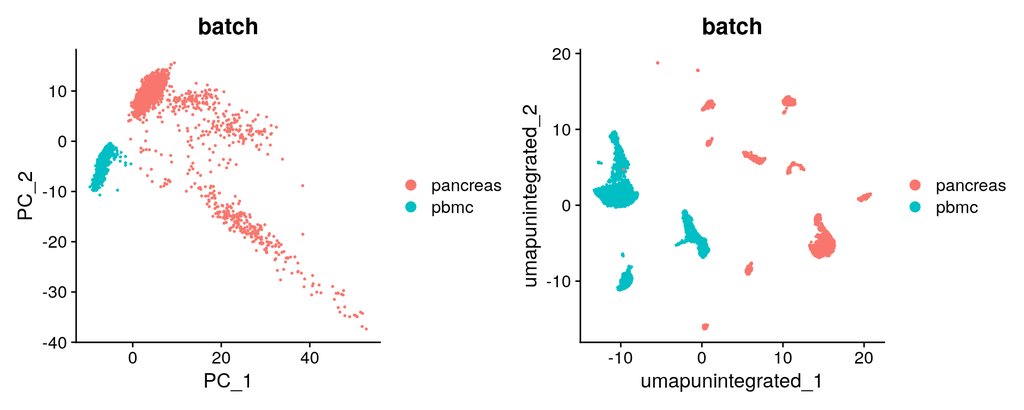

```r
## Plot jointly dimreds
pca.unint <- DimPlot(seu, reduction = "pca", group.by = "batch")
umap.unint <- DimPlot(seu, reduction = "umap.unintegrated", group.by = "batch")
pca.unint + umap.unint
```

### Celltype markers

*(5 min)*

> AIM: Check if cells from different datasets share well-known cell-specific markers.

Plot below some cell-specific PBMC or pancreatic cell type markers. Feel free to add other genes you might be interested in checking.

```r
## Joint celltype markers

# List of PBMC and (some) pancreatic cell markers
markers.plot <- list(
  # "pbmc" = c("CD3D", "CREM", "HSPH1", "SELL", "GIMAP5", "CACYBP", "GNLY", "NKG7", "CCL5",
  #            "CD8A", "MS4A1", "CD79A", "MIR155HG", "NME1", "FCGR3A", "VMO1", "CCL2", "S100A9",
  #            "HLA-DQA1", "GPR183", "PPBP", "GNG11", "HBA2", "HBB", "TSPAN13", "IL3RA", "IGJ",
  #            "PRSS57"),
  "pbmc" = c("CD3D", "NKG7", "CD8A", "MS4A1", "CD79A", "FCGR3A"),
  "pancreas" = c("REG1A", "PPY", "SST", "GHRL", "VWF", "SOX10")
)

# Plot
pbmc.markers.unint.plot <- FeaturePlot(seu, features = markers.plot$pbmc, split.by = "batch",
                                       max.cutoff = 3, cols = c("grey", "red"),
                                       reduction = "umap.unintegrated", ncol = 4, pt.size = 0.1)
pancreas.markers.unint.plot <- FeaturePlot(seu, features = markers.plot$pancreas, split.by = "batch",
                                           max.cutoff = 3, cols = c("grey", "red"),
                                           reduction = "umap.unintegrated", ncol = 4, pt.size = 0.1)
```

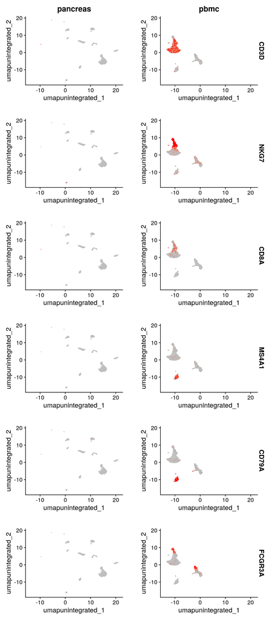

```r
## Plot jointly celltype markers

# Print
pbmc.markers.unint.plot
```

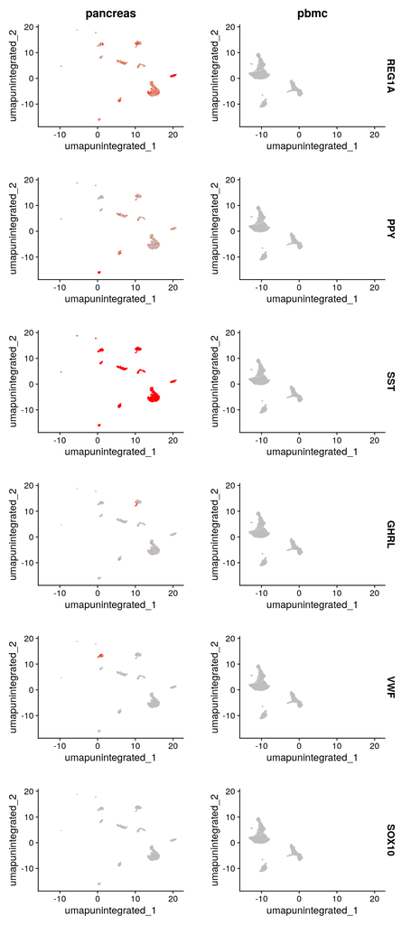

```r
pancreas.markers.unint.plot
```

### Manual cell annotation

*(15 min)*

> AIM: Check the number of differentially expressed genes for dataset-specific clusters shared between datasets.

Split the `Seurat` object into a list of two `Seurat` objects (one per dataset) and run the standard `Seurat` workflow for each. After calculating the PCA, run `FindNeighbors()` and `FindClusters()` sequentially to perform graph-based clustering for each dataset, in order to determine the dataset-specific cluster markers.

```r
## Independent sample analysis

# Split Seurat object into two batch on 'batch' label identity
seu.list <- SplitObject(object = seu, split.by = "batch")

# Standard Seurat upstream workflow
seu.list <- lapply(X = seu.list, FUN = function(x) {
  x <- NormalizeData(x)
  x <- FindVariableFeatures(x)
  x <- ScaleData(x)
  x <- RunPCA(x)
  x <- FindNeighbors(x, dims = 1:15, reduction = "pca")
  x <- FindClusters(x, resolution = 0.8, cluster.name = "unintegrated_clusters")
  x <- RunUMAP(x, dims = 1:15, reduction = "pca", reduction.name = "umap.unintegrated")
})
```

```
## Modularity Optimizer version 1.3.0 by Ludo Waltman and Nees Jan van Eck
##
## Number of nodes: 2700
## Number of edges: 108625
##
## Running Louvain algorithm...
## Maximum modularity in 10 random starts: 0.8180
## Number of communities: 9
## Elapsed time: 0 seconds
## Modularity Optimizer version 1.3.0 by Ludo Waltman and Nees Jan van Eck
##
## Number of nodes: 1937
## Number of edges: 65621
##
## Running Louvain algorithm...
## Maximum modularity in 10 random starts: 0.8659
## Number of communities: 12
## Elapsed time: 0 seconds
```

Plot UMAPs for both datasets highlighting the `Seurat` clusters found for each.

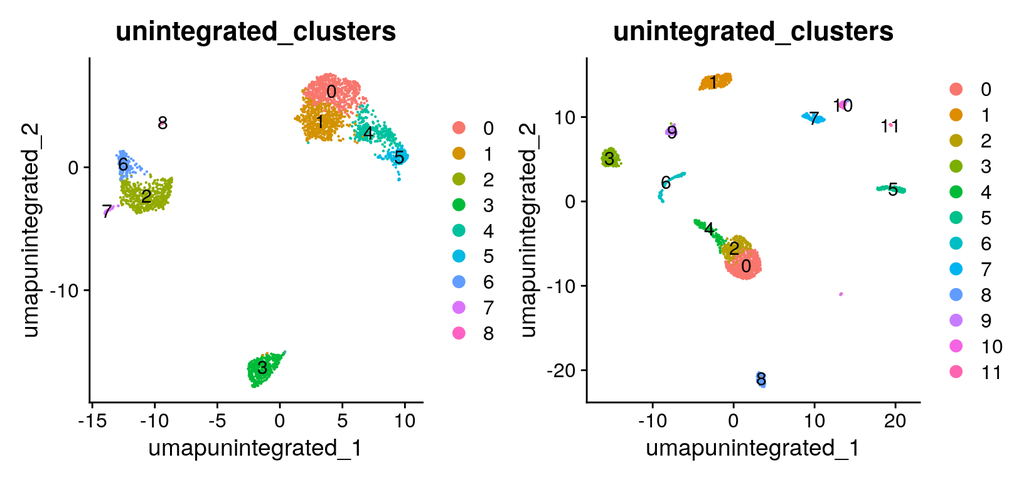

```r
## Plot independent sample analysis clusters
umap.ind.samp.unint <- lapply(X = seu.list, FUN = function(x) {
  DimPlot(x, reduction = "umap.unintegrated", group.by = "unintegrated_clusters", pt.size = 0.1, label = TRUE)
})
umap.ind.samp.unint$pbmc + umap.ind.samp.unint$pancreas
```

Compute the differentially expressed genes for every cluster in every dataset and retrieve only the upregulated genes for every cluster. Then pick the top 50 upregulated genes per cluster based on log2 fold-change, among those you were statistically significant, i.e., FDR<0.05, and calculate the intersection of cluster genes between datasets.

```r
## Independent sample analysis: DGE

# Differential gene expression analysis per cluster
dge.markers.unint <- lapply(X = seu.list, FUN = function(x) {
  FindAllMarkers(object = x, assay = "RNA", slot = "data",
                 logfc.threshold = 0.25, min.pct = 0.25,
                 min.cells.feature = 10, only.pos = TRUE)
})

# Pick the top50 upregulated genes per cluster based on log2FC
top50.up.cluster <- lapply(X = dge.markers.unint, FUN = function(x) {
  x %>%
    filter(p_val_adj<0.05) %>%
    group_by(cluster) %>%
    arrange(desc(avg_log2FC)) %>%
    slice_head(n=50)  %>%
    split(., .$cluster)
})

# Check intersection of top50 marker genes between clusters across batches
shared.genes <- list()
for (i in names(top50.up.cluster$pbmc)) {
  for (ii in names(top50.up.cluster$pancreas)) {
    shared.genes[[paste0("pbmc", i)]][[paste0("pancreas", ii)]] <- intersect(top50.up.cluster$pbmc[[i]]$gene,
                                                                             top50.up.cluster$pancreas[[ii]]$gene)
  }
}
# Table with number of genes shared between pbmc vs pancreas clusters for the top50 upregulated genes per cluster
shared.genes.table <- as.data.frame(
  lapply(X = shared.genes, FUN = function(x) {
    unlist(lapply(x, length))
  })
)
```

Print the confusion matrix of cluster markers shared between datasets.

```r
## Print table
knitr::kable(shared.genes.table)
```

[output not shown]

Plot the previous table as a heatmap.

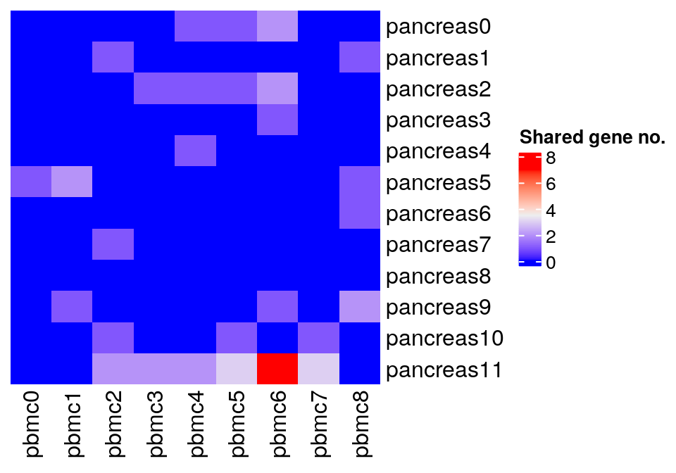

```r
## Plot independent sample analysis clusters
ComplexHeatmap::Heatmap(matrix = as.matrix(shared.genes.table), name = "Shared gene no.",
                        cluster_columns = FALSE, cluster_rows = FALSE)
```

### Automatic cell annotation

*(10 min)*

> AIM: Check if datasets share cell types by predicting cell type labels for both datasets.

This exercise requires to run [CellTypist](https://www.celltypist.org/). `CellTypist` is a python package that can be run using python, the command-line or online through their website. For convenience, run `CellTypist` online.

```r
## Automatic cell annotation
file.name <- file.path(res.dir[3], "pbmc3k_panc8_celltypist.h5ad")
cat("Exporting Seurat object as '.h5ad' format to:", gsub("\\../", "", file.name), "\n")
```

```
## Exporting Seurat object as '.h5ad' format to: results/cross_tissue_task/objects/pbmc3k_panc8_celltypist.h5ad
```

```r
zellkonverter::writeH5AD(sce = as.SingleCellExperiment(seu), file = file.name, X_name = "logcounts")
```

You should receive an e-mail with a download link with the result. Download the result - `predictions.tar.gz` - and put the result into the directory: `results/cross_tissue_task/tables`. In alternative, you can substitute the url below (because it’s only valid for 7 days) by copying and pasting the link you received in your own e-mail and replace the variable `FALSE` by `TRUE` for the variable `use.url`.

Plot the predicted labels for both data sets.

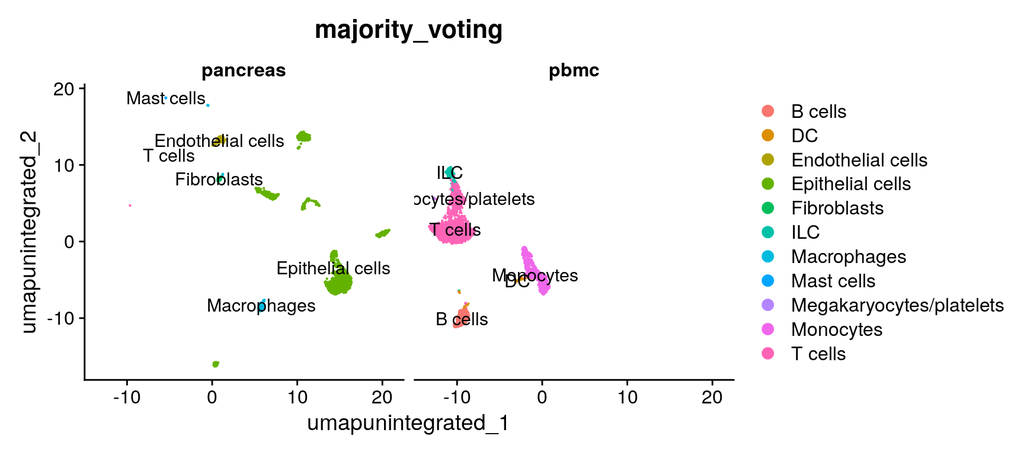

```r
## Plot labels from CellTypist

# Download predictions
use.url <- FALSE # if you wanna use the url, replace the url by the url you received in your e-mail and replace FALSE by TRUE
if (use.url) { # download: url only valid for 7 days
  url <- "https://celltypist.cog.sanger.ac.uk/uploads/9cd807d8-69de-4b7c-a827-70e51c4a8b4a/predictions.tar.gz?AWSAccessKeyId=C068AUIY7F6SNEJUTEPA&Signature=XY4lL4D%2FWnuuBhV5%2BDOCimkyxSk%3D&Expires=1720176188"
  download.file(url = url, destfile = file.path(res.dir[2], "predictions.tar.gz"))
}
# Decompress the file with predictions
untar(tarfile = file.path(res.dir[2], "predictions.tar.gz"), exdir = res.dir[2])

# Add predictions to Seurat object
seu@meta.data[,c("predicted_labels", "over_clustering", "majority_voting")] <- read.table(file = file.path(res.dir[2],
                                                                                                           "predicted_labels.csv"),
                                                                                          header = TRUE, sep = ",", row.names = 1)

# Plot predictions
DimPlot(object = seu, reduction = "umap.unintegrated", group.by = "majority_voting",
        split.by = "batch", pt.size = 0.1, label = TRUE)
```

## (3) Integrate datasets

*(10 min)*

> AIM: Compare different integration methods.

First, `split` the layers of data by batch before performing integration. Then, apply the standard `Seurat` workflow. Finally, call the function `IntegrateLayers()` to integrate the datasets. In this function you can specify the method you want to run by providing the integration method function.

`Seurat` provides three methods: CCA (`CCAIntegration`), RPCA (`RPCAIntegration`) and Harmony (`HarmonyIntegration`). In addition, other methods can be called by using functions from `SeuratWrappers` such as: FastMNN (`FastMNNIntegration`) or scVI (`scVIIntegration`) among others. Harmony (from the `harmony` R package), FastMNN (from the `batchelor` R package) and scVI (python package installed with conda) need to be installed independently from `Seurat`.

Run the R chunk code below to run the integration methods: CCA, RPCA, Harmony and FastMNN (you can try to run scVI if you’ve it installed in your system). Join the layers back after integration to project the integrated data onto UMAP. The UMAP highlights the `batch` and ground-truth `cell_type` labels.

```r
## Perform integration

# Split layers for integration
seu[["RNA"]] <- split(x = seu[["RNA"]], f = seu$batch)

# Standard workflow
seu <- NormalizeData(seu)
seu <- FindVariableFeatures(seu)
seu <- ScaleData(seu)
seu <- RunPCA(seu)

# Integrate layers
int.methods <- c("CCA" = "CCAIntegration", "RPCA" = "RPCAIntegration",
                 "Harmony" = "HarmonyIntegration", "FastMNN" = "FastMNNIntegration",
                 "scVI" = "scVIIntegration")

for (m in names(int.methods)[1:4]) {
  cat("\nRunning integration method", m, "...\n")
  int.dimred <- paste0("integrated.", m)
  umap.dimred <- paste0("umap.", m)
  # Integration
  if (m=="RPCA") {
      seu <- IntegrateLayers(object = seu, method = get(eval(substitute(int.methods[m]))),
                             orig.reduction = "pca",
                             new.reduction = int.dimred,
                             k.weight = 50, # otherwise it aborts
                             verbose = TRUE)
  } else if (m=="scVI") {
          seu <- IntegrateLayers(object = seu, method = get(eval(substitute(int.methods[m]))),
                                 orig.reduction = "pca",
                                 new.reduction = int.dimred,
                                 conda_env = "~/miniconda3/envs/scvi-env", # substitute this by your installation
                                 verbose = TRUE)
  } else {
      seu <- IntegrateLayers(object = seu, method = get(eval(substitute(int.methods[m]))),
                             orig.reduction = "pca",
                             new.reduction = int.dimred,
                             verbose = TRUE)
  }

}
```

```
##
## Running integration method CCA ...
##
## Running integration method RPCA ...
##
## Running integration method Harmony ...
##
## Running integration method FastMNN ...
```

```r
# Re-join layers after integration
seu[["RNA"]] <- JoinLayers(seu[["RNA"]])

# Run UMAP for every integration method
int.umaps.plots <- list()
for (m in names(int.methods)[1:4]) {
  cat("\nRunning UMAP for", m, "integrated result...\n")
  int.dimred <- paste0("integrated.", m)
  umap.dimred <- paste0("umap.", m)
  seu <- RunUMAP(seu, dims = 1:30, reduction = int.dimred, reduction.name = umap.dimred)
  int.umaps.plots[[m]] <-  DimPlot(object = seu, reduction = umap.dimred, group.by = c("batch", "cell_type"),
                                   combine = FALSE, label.size = 2, pt.size = 0.1)
}
```

```
##
## Running UMAP for CCA integrated result...
##
## Running UMAP for RPCA integrated result...
##
## Running UMAP for Harmony integrated result...
##
## Running UMAP for FastMNN integrated result...
```

```r
# Save Seurat object
saveRDS(object = seu, file = file.path(res.dir[3], "seu_integrated.rds"))
```

## (4) Assess integration

*(15 min)*

> AIM: Assess integration qualitatively and quantitatively through dimensional reduction visualizations and LISI scores.

### Qualitative viz

Plot the integrated embeddings below highlighting the `batch` and ground-truth `cell_type` labels.

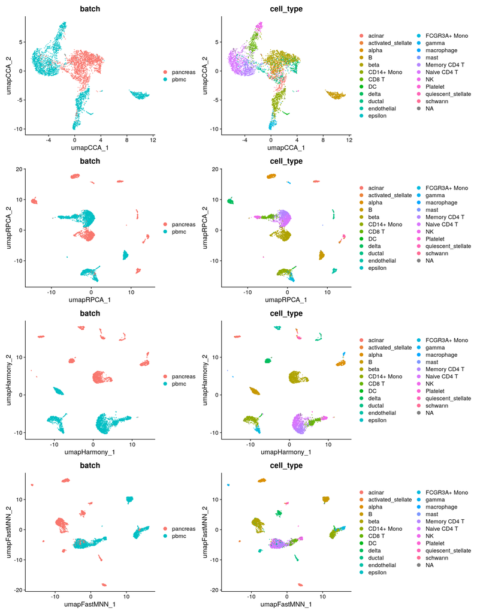

```r
## Assess integration by printing the plots using the "batch" and "cell_type" (ground-truth) labels
wrap_plots(c(int.umaps.plots$CCA, int.umaps.plots$RPCA, int.umaps.plots$Harmony, int.umaps.plots$FastMNN),
           ncol = 2, byrow = TRUE)
```

### Quantitative metrics

Run the code below to compute the i/cLISI scores for every integrated embedding with the function `getIntegrationMetrics()` from the package `scIntegrationMetrics` (read more about the meaning of these metrics [here](https://github.com/carmonalab/scIntegrationMetrics)).

```r
## Assess quantitatively integration with scIntegrationMetrics

# Calculate metrics
int.mthds.names <- paste0("integrated.", names(int.methods)[1:4])
names(int.mthds.names) <- int.mthds.names
metrics <- list()
for (m in int.mthds.names) {
  key <- gsub("integrated.", "", m)
  cat("Computing i/cLISI metrics for integration method:", gsub("integrated.", "", key), "\n")
  metrics[[key]] <- getIntegrationMetrics(seu, meta.label = "cell_type", meta.batch = "batch",
                                          method.reduction = m, metrics = c("iLISI", "norm_iLISI",
                                                                            #"CiLISI", "CiLISI_means",
                                                                            "norm_cLISI", "norm_cLISI_means"))
}
```

```
## Computing i/cLISI metrics for integration method: CCA
## Computing i/cLISI metrics for integration method: RPCA
## Computing i/cLISI metrics for integration method: Harmony
## Computing i/cLISI metrics for integration method: FastMNN
```

```r
# Join metrics
metrics <- as.data.frame(do.call(cbind, metrics))
```

Print the result below.

```r
# Print table
knitr::kable(metrics)
```

|  | CCA | RPCA | Harmony | FastMNN |
| --- | --- | --- | --- | --- |
| iLISI | 1.100594 | 1.02563 | 1.004797 | 1.035199 |
| norm_iLISI | 0.1005943 | 0.02562982 | 0.004796592 | 0.03519914 |
| norm_cLISI | 0.9452894 | 0.9424586 | 0.9591123 | 0.9403612 |
| norm_cLISI_means | 0.917104 | 0.9022 | 0.932591 | 0.9084225 |